# santos_petrie_11.7.23

Daniel Petrie

2023-11-07

Global settings

```r
library("ipumsr") #Useful for census, survey, and geographic data provided by IPUMS
library("ltm") #?
library("survey") #?
library("tidyverse") #Data manipulation
library("gtsummary")
library("flextable")
library("expss")
library("ggplot2") #For plotting
library("ggeffects") #For marginal/conditional effects plots
library("margins") #For margins() function. Useful for comparing margins from ggeffects
library("marginaleffects") #For hypothesis_test()
library("parameters")

#Set working directory
setwd("C:/Users/djpet/OneDrive - The Pennsylvania State University/Other manuscripts/Alexis")

#Data
ddi <- read_ipums_ddi("C:/Users/djpet/OneDrive - The Pennsylvania State University/Other manuscripts/Alexis/nhis_00090.xml")
data <- read_ipums_micro(ddi)

#Looking at first few rows.
head(data)
```

```
## # A tibble: 6 × 31
##    YEAR SERIAL STRATA    PSU   NHISHID HHWEIGHT PERNUM NHISPID HHX   FMX   PX
##   <dbl>  <dbl> <dbl+lbl> <dbl> <chr>      <dbl>  <dbl> <chr>   <chr> <chr> <chr>
## 1  1997      8 5142      2     000019…     1760      1 001997… 0003… 01    01
## 2  1997      8 5142      2     000019…     1760      2 001997… 0003… 01    02
## 3  1997      8 5142      2     000019…     1760      3 001997… 0003… 01    03
## 4  1997      8 5142      2     000019…     1760      4 001997… 0003… 01    04
## 5  1997      9 5095      2     000019…     1103      1 001997… 0003… 01    01
## 6  1997      9 5095      2     000019…     1103      2 001997… 0003… 01    02
## # ℹ 20 more variables: PERWEIGHT <dbl>, SAMPWEIGHT <dbl>, FWEIGHT <dbl>,
## #   ASTATFLG <int+lbl>, CSTATFLG <int+lbl>, AGE <dbl+lbl>, SEX <int+lbl>,
## #   RACENEW <int+lbl>, HISPYN <int+lbl>, EDUCREC2 <int+lbl>,
## #   EDUCREC1 <int+lbl>, EDUC <int+lbl>, HEALTH <int+lbl>, AEFFORT <int+lbl>,
## #   AFEELINT1MO <int+lbl>, AHOPELESS <int+lbl>, ANERVOUS <int+lbl>,
## #   ARESTLESS <int+lbl>, ASAD <int+lbl>, AWORTHLESS <int+lbl>
```

Cleaning code chunk. For reproducibility, I’m retaining all Alexis cleaning code below. I removed code chunks that either were hashed out, or code chunks that were for making data tables. Happy to add those in later.

```r
#Only keep Adult Sample
#See IPUMS Universe for Worry: https://nhis.ipums.org/nhis-action/variables/WORFREQ#universe_section


#Create outcome "severe psychological distress". This looks like a composite score type of measure.
data2<-subset(data,ASTATFLG==1)
data2<-subset(data2,AEFFORT<5) #Eliminate those Not in the Universe
data2<-subset(data2,AFEELINT1MO<5)  #Eliminate missing values
data2<-subset(data2,AHOPELESS<5)
data2<-subset(data2,ANERVOUS<5)
data2<-subset(data2,ARESTLESS<5)
data2<-subset(data2,ASAD<5)
data2<-subset(data2,AWORTHLESS<5)
data2<-subset(data2,AGE>17) #Keep people over 18 nOTHING cHANGES

#Creating the actual count variable.
data2$distress_score<-data2$AEFFORT+
  data2$AHOPELESS+data2$ANERVOUS+data2$ARESTLESS+
  data2$ASAD+data2$AWORTHLESS

#Making it dichotomous
data2$distress<-ifelse(data2$distress_score>12,1,0)

#Subsetting people with health data present. The variable SRH_dummy might not be needed.
data2$SRH_dummy<-ifelse(data2$HEALTH>3,1,0)
data2<-subset(data2,HEALTH<6)

#Creating ethnicity factor variable.
data2$reth<-as.factor(ifelse(data2$HISPYN == 2, "Latine",
                          ifelse(data2$RACENEW == 400, "Non-Latine Asian",
                                 ifelse(data2$RACENEW == 200, "Non-Latine Black/AA",
                                        ifelse(data2$RACENEW == 100, "Non-Latine White",
                                               "Other")))))


data2<-subset(data2,EDUC>001)
data2<-subset(data2,EDUC<600)

data2$agestage<-ifelse(data2$AGE<60,"Midage","Older")


data2$reth<-factor(data2$reth,levels=c("Non-Latine Asian","Non-Latine Black/AA","Non-Latine Other","Latine","Non-Latine White"))
data2$reth<-relevel(data2$reth,ref = "Non-Latine White")

data2$male<-ifelse(data2$SEX==1,"Male","Female")

data2$educ1<-ifelse(data2$EDUC<201,"Below HS",
                   ifelse(data2$EDUC<204,"HS/GED",
                          ifelse(data2$EDUC<302,"Some college",
                                 ifelse(data2$EDUC<303,"AA",
                                        ifelse(data2$EDUC<304,"AA",
                                               ifelse(data2$EDUC<401,"BA",
                                                      "More than BA"))))))


data2$educ1<-relevel(as.factor(data2$educ1),ref = "HS/GED")

data$SAMPWEIGHT<-(data$SAMPWEIGHT/22)

#Puts labels in the Variable
library(expss)
data=apply_labels(data,n_index2="Neighborhood Cohesion Index",
                  worry_flip="Frequency of Worry, Nervous or Anxious",
                  worry_dummy="Daily/Weekly Worry",
                  reth="Race/Ethnicity",
                  NBHDTIME="Time living in neighborhood",
                  marital="Marital Status",
                  AGE="Age at the time of interview",
                  educ1="Educational attainment",
                  male="Sex",
                  poor="Poverty status")
#Something weird with this command getting a warning... will leave it alone for now?
```

From my understanding, the “des” (i.e., design) argument is required, and does some fancy weighted stuff for survey data? Best guess is to have a “nationally representative” data set.

```r
#Runs Survey Weighted Models
options(survey.lonely.psu="adjust")
des<-svydesign(ids=~PSU,strata=~STRATA,weights=~SAMPWEIGHT, nest=TRUE,data=data2)
#Line below does not work.
#svymean(~data$n_close+data$n_counton+data$n_help+data$n_trust,design=des)
```

# Using R to explore Interaction Effects

## Petrie, Daniel J., The Pennsylvania State University

## Santos-Lozada, Alexis R., The Pennsylvania State University

**Abstract**

This tutorial introduces the use of R to explore interaction effects in social and behavioral sciences.

**Keywords**

R, interaction effects, open materials

**Data**

**The R Environment**

Note, that while we will be analyzing national data using the survey library, all of these processes will work on any data set.

**Intercept-only model**

An intercept-only logistic regression model is useful as a baseline model to compare with more complex logistic regression models that include various predictor variables and interactions. For example, using the NHIS data, we can fit an intercept-only logistic regression model with the following ccommand.

```r
model_int <- svyglm(distress ~ 1,
                    design = des,
                    family = "quasibinomial")
```

The summary() function is used to produce result summaries of various model fitting functions. We can examine the summary of the intercept-only logistic regression model with the following command.

```r
summary(model_int)
```

```
##
## Call:
## svyglm(formula = distress ~ 1, design = des, family = "quasibinomial")
##
## Survey design:
## svydesign(ids = ~PSU, strata = ~STRATA, weights = ~SAMPWEIGHT,
##     nest = TRUE, data = data2)
##
## Coefficients:
##             Estimate Std. Error t value Pr(>|t|)
## (Intercept) -3.41090    0.01156    -295   <2e-16 ***
## ---
## Signif. codes:  0 '***' 0.001 '**' 0.01 '*' 0.05 '.' 0.1 ' ' 1
##
## (Dispersion parameter for quasibinomial family taken to be 1.000002)
##
## Number of Fisher Scoring iterations: 6
```

The intercept parameter (b0 = -3.41) reflects the expected log-odds of an individual to report psychological distress. However, parameter estimates from logistic regression are often reported in terms of odds rather than log-odds. To obtain parameters in odds units, one can simply exponentiate (e.g., exp()) the coefficient b0. Alternatively, one can also use the model_parameters() command from the “parameters” package.

```r
#Option 1: exp(b0)
exp(-3.41090)
```

```
## [1] 0.03301148
```

```r
#Option 2: model_parameters(model, exponentiate = TRUE)
model_parameters(model_int,
                 exponentiate = TRUE)
```

```
## Parameter   | Odds Ratio |       SE |       95% CI | t(1246) |      p
## ---------------------------------------------------------------------
## (Intercept) |       0.03 | 3.82e-04 | [0.03, 0.03] | -294.98 | < .001
```

```
##
## Uncertainty intervals (equal-tailed) and p-values (two-tailed) computed
##   using a Wald t-distribution approximation.
```

Now, the intercept parameter is in odds units; there is a 0.03 (3%) odds of reporting psychological distress.

**Model 0a: Main effects model with one dichotomous predictor**

Now, we will add a categorical predictor, sex assigned at birth (0 = Female, 1 = Male) to the model.

```r
model0a <- svyglm(distress ~ 1 + male,
                design = des,
                family = "quasibinomial")
summary(model0a)
```

```
##
## Call:
## svyglm(formula = distress ~ 1 + male, design = des, family = "quasibinomial")
##
## Survey design:
## svydesign(ids = ~PSU, strata = ~STRATA, weights = ~SAMPWEIGHT,
##     nest = TRUE, data = data2)
##
## Coefficients:
##             Estimate Std. Error t value Pr(>|t|)
## (Intercept) -3.22791    0.01285 -251.15   <2e-16 ***
## maleMale    -0.42324    0.01841  -22.99   <2e-16 ***
## ---
## Signif. codes:  0 '***' 0.001 '**' 0.01 '*' 0.05 '.' 0.1 ' ' 1
##
## (Dispersion parameter for quasibinomial family taken to be 1.000002)
##
## Number of Fisher Scoring iterations: 6
```

Notice that the intercept parameter (b0 = -3.23) has changed. It now reflects the expected log-odds of females to report psychological distress. The estimate for b1 indicates the expected difference of the log-odds of reporting distress for being male. Therefore, we expect a –0.42 difference in the log-odds of reporting distress for being male.

Let’s look at these coefficients in odds units.

```r
model_parameters(model0a,
                 exponentiate = TRUE)
```

```
## Parameter   | Odds Ratio |       SE |       95% CI | t(1245) |      p
## ---------------------------------------------------------------------
## (Intercept) |       0.04 | 5.09e-04 | [0.04, 0.04] | -251.15 | < .001
## male [Male] |       0.65 |     0.01 | [0.63, 0.68] |  -22.99 | < .001
```

```
##
## Uncertainty intervals (equal-tailed) and p-values (two-tailed) computed
##   using a Wald t-distribution approximation.
```

So far, we have only considered two ways of interpreting logistic regression results: (1) Interpreting the log-odds directly, (2) Transforming log-odds into an odds ratio. However, as model complexity grows, interpretation in log-odds and odds units becomes more cumbersome and difficult. For nonlinear models, it is often useful to use marginal effects, which is an intuitive way to understand logistic regression results. Marginal effects have the additional benefit of being reported in probability units, which tend to be easier to interpret.

Briefly, marginal effects refer to the change in the expected value of a response/dependent variable resulting from a change in one independent variable while holding other variables constant. Marginal effects can be calculated for dichotomous, categorical, or continuous variables. In a logistic regression context, marginal effects of dichotomous and categorical variables typically indicate how the probability of an outcome changes in response to change in the dichotomous/categorical variable. Marginal effects of continuous variables typically indicate how the probability of an outcome changes based on changes in the values of a predictor variable. Using model 0 as an example, marginal effects can answer the question “How does sex assigned at birth affect the probability of reporting distress?”.

*NEED TO FIT THIS IN SOMEWHERE!*

It is important to note that if Bj > 0 then exp(Bj) > 1, indicating a positive relationship between Xj and the probability of the event occurring. If Bj < 0 then exp(Bj) < 1, indicating a negative relationship between Xi and the probability of the event occurring. In other words, if the odds ratio is greater than one, then the probability of the event occurring is more likely, and if the odds ratio is less than one, then the probability of the event occurring is less likely.

Marginal effects can be estimated using the ggpredict() function from the “ggeffects” package.

```r
marginal_effects_mod0a <- ggpredict(model0a,
                                   terms = c("male"))
```

The first argument specifies the model of interest, and the terms argument specifies the contrast of interest. Here, we want to examine differences in the probability of reporting distress for females and males so we enter “male” as out contrast.

```r
marginal_effects_mod0a
```

```
## # Predicted probabilities of distress
##
## male   | Predicted |       95% CI
## ---------------------------------
## Female |      0.04 | [0.04, 0.04]
## Male   |      0.03 | [0.02, 0.03]
```

First, ggpredict() returns the predicted probabilities reporting distress for females and males with the associated 95% CIs. The predicted probabilities are similar in magnitude, in that females have a 4% chance of reporting distress compared to males with a 3% chance of reporting distress.

An additional function margins() from the “margins” package can also be used to calculate the average marginal effect in the probability of reporting distress between females and males.

```r
margins(model0a, design = des)
```

```
## Average marginal effects (survey-weighted)
```

```
## svyglm(formula = distress ~ 1 + male, design = des, family = "quasibinomial")
```

```
##  maleMale
##  -0.01282
```

On average, being male decreases the predicted probability of reporting distress by 1.3%.

An additional function to be aware of in the “ggeffects” package is the hypothesis_test() function, which tests differences in contrasts or comparisons of interest for statistical significance.

```r
hypothesis_test(marginal_effects_mod0a)
```

```
## # Pairwise comparisons
##
## male        | Contrast |       95% CI |      p
## ----------------------------------------------
## Female-Male |     0.01 | [0.01, 0.01] | < .001
```

```
##
## Contrasts are presented as probabilities.
```

Here we see that, similar to the margins() function, the contrast of Female – Male is 0.01, and is significant at an alpha of 0.05.

Finally, plotting the predicted probabilities for each group is also simple, using the plot() function.

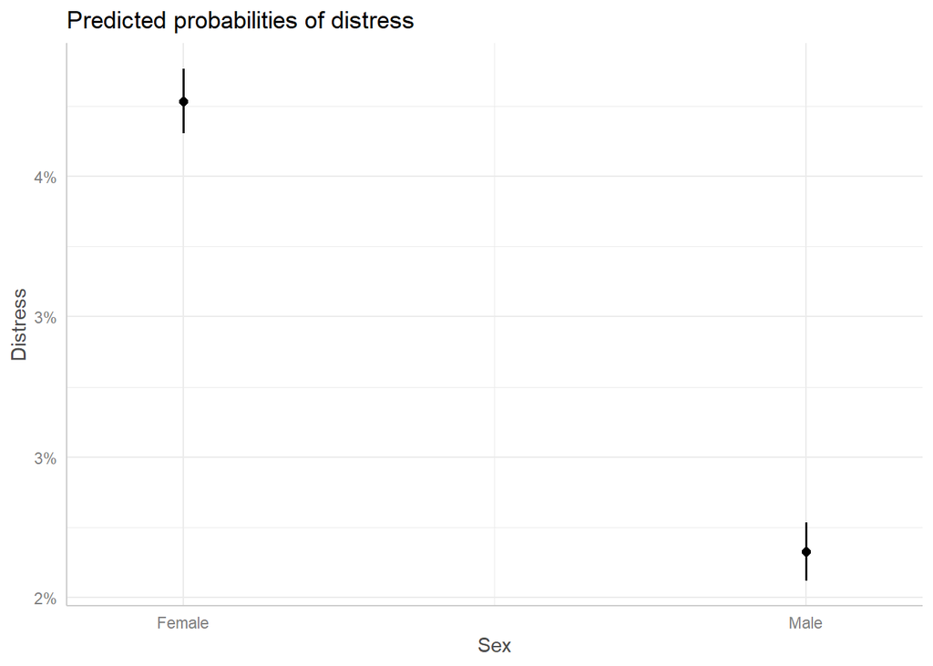

```r
#Plot
plot(marginal_effects_mod0a) +
  labs(x = "Sex",
       y = "Distress")
```

**Model 0b: Main effects model with multiple predictors**

Now we will add some predictors of psychological distress to the model. Specifically, we will add education (educ1) and year (YEAR) as covariates. Predictors of interest are ethnicity (reth), sex assigned at birth (male), and age (AGE).

```r
model0b <- svyglm(distress ~ 1 + reth + AGE + educ1 + male + YEAR,
                design = des,
                family = "quasibinomial")
summary(model0b)
```

```
##
## Call:
## svyglm(formula = distress ~ 1 + reth + AGE + educ1 + male + YEAR,
##     design = des, family = "quasibinomial")
##
## Survey design:
## svydesign(ids = ~PSU, strata = ~STRATA, weights = ~SAMPWEIGHT,
##     nest = TRUE, data = data2)
##
## Coefficients:
##                           Estimate Std. Error t value Pr(>|t|)
## (Intercept)             -4.947e+01  3.722e+00 -13.292  < 2e-16 ***
## rethNon-Latine Asian    -5.399e-01  6.416e-02  -8.415  < 2e-16 ***
## rethNon-Latine Black/AA -8.342e-02  2.884e-02  -2.893  0.00389 **
## rethLatine              -2.250e-01  2.857e-02  -7.876 7.34e-15 ***
## AGE                     -2.026e-03  4.856e-04  -4.172 3.23e-05 ***
## educ1AA                 -3.506e-01  3.629e-02  -9.659  < 2e-16 ***
## educ1BA                 -1.098e+00  4.005e-02 -27.418  < 2e-16 ***
## educ1Below HS            5.931e-01  2.648e-02  22.397  < 2e-16 ***
## educ1More than BA       -1.372e+00  5.559e-02 -24.676  < 2e-16 ***
## educ1Some college       -2.250e-01  2.751e-02  -8.178 7.09e-16 ***
## maleMale                -4.404e-01  1.962e-02 -22.449  < 2e-16 ***
## YEAR                     2.318e-02  1.856e-03  12.487  < 2e-16 ***
## ---
## Signif. codes:  0 '***' 0.001 '**' 0.01 '*' 0.05 '.' 0.1 ' ' 1
##
## (Dispersion parameter for quasibinomial family taken to be 1.026013)
##
## Number of Fisher Scoring iterations: 7
```

Notice here that the only predictors that have increased odds of reporting distress are individuals who reported that they did not graduate high school, and year, such that the probability of reporting distress increased as the year of survey increased.

We can also look at main effects of interest as marginal effects. We already looked at the sex (e.g., male) contrast.

```r
ggpredict(model0b,
          terms = "male")
```

```
## # Predicted probabilities of distress
##
## male   | Predicted |       95% CI
## ---------------------------------
## Female |      0.05 | [0.05, 0.05]
## Male   |      0.03 | [0.03, 0.03]
##
## Adjusted for:
## *  reth = Non-Latine White
## *   AGE =            46.08
## * educ1 =           HS/GED
## *  YEAR =          2008.75
```

Now, we will examine the other main effects of interest: ethnicity and age.

```r
#Ethnicity probabilities
ggpredict(model0b,
          terms = "reth")
```

```
## # Predicted probabilities of distress
##
## reth                | Predicted |       95% CI
## ----------------------------------------------
## Non-Latine White    |      0.05 | [0.05, 0.05]
## Non-Latine Asian    |      0.03 | [0.02, 0.03]
## Non-Latine Black/AA |      0.04 | [0.04, 0.05]
## Latine              |      0.04 | [0.04, 0.04]
##
## Adjusted for:
## *   AGE =   46.08
## * educ1 =  HS/GED
## *  male =  Female
## *  YEAR = 2008.75
```

```r
#Age probabilities
ggpredict(model0b,
          terms = "AGE[all]")
```

```
## # Predicted probabilities of distress
##
## AGE | Predicted |       95% CI
## ------------------------------
##  18 |      0.05 | [0.05, 0.05]
##  26 |      0.05 | [0.05, 0.05]
##  35 |      0.05 | [0.05, 0.05]
##  43 |      0.05 | [0.05, 0.05]
##  51 |      0.05 | [0.04, 0.05]
##  60 |      0.05 | [0.04, 0.05]
##  68 |      0.05 | [0.04, 0.05]
##  85 |      0.04 | [0.04, 0.05]
##
## Adjusted for:
## *  reth = Non-Latine White
## * educ1 =           HS/GED
## *  male =           Female
## *  YEAR =          2008.75
```

```
##
## Not all rows are shown in the ouput. Use `print(..., n = Inf)` to show
##   all rows.
```

From the main effects, we can see that: (1) Females have a higher probability of reporting distress than males; (2) Probability of reporting distress varies by ethnicity, and (3) there is a small effect of age, such that the probability of reporting distress deceases across age.

The ggpredict() function can also handle multiple predictors at once. This allows users to examine marginal effect contrasts across multiple grouping variables.

```r
ggpredict(model0b,
          terms = c("AGE[all]", "reth", "male"))
```

```
## # Predicted probabilities of distress
##
## # reth = Non-Latine White
## # male = Female
##
## AGE | Predicted |       95% CI
## ------------------------------
##  18 |      0.05 | [0.05, 0.05]
##  35 |      0.05 | [0.05, 0.05]
##  51 |      0.05 | [0.04, 0.05]
##  85 |      0.04 | [0.04, 0.05]
##
## # reth = Non-Latine Asian
## # male = Female
##
## AGE | Predicted |       95% CI
## ------------------------------
##  18 |      0.03 | [0.03, 0.03]
##  35 |      0.03 | [0.03, 0.03]
##  51 |      0.03 | [0.02, 0.03]
##  85 |      0.03 | [0.02, 0.03]
##
## # reth = Non-Latine Black/AA
## # male = Female
##
## AGE | Predicted |       95% CI
## ------------------------------
##  18 |      0.05 | [0.04, 0.05]
##  35 |      0.04 | [0.04, 0.05]
##  51 |      0.04 | [0.04, 0.05]
##  85 |      0.04 | [0.04, 0.04]
##
## # reth = Latine
## # male = Female
##
## AGE | Predicted |       95% CI
## ------------------------------
##  18 |      0.04 | [0.04, 0.04]
##  35 |      0.04 | [0.04, 0.04]
##  51 |      0.04 | [0.04, 0.04]
```

[output cut: 30 more lines]

```
##  85 |      0.03 | [0.02, 0.03]
##
## # reth = Latine
## # male = Male
##
## AGE | Predicted |       95% CI
## ------------------------------
##  18 |      0.03 | [0.02, 0.03]
##  35 |      0.03 | [0.02, 0.03]
##  51 |      0.02 | [0.02, 0.03]
##  85 |      0.02 | [0.02, 0.02]
##
## Adjusted for:
## * educ1 =  HS/GED
## *  YEAR = 2008.75
```

```
##
## Not all rows are shown in the ouput. Use `print(..., n = Inf)` to show
##   all rows.
```

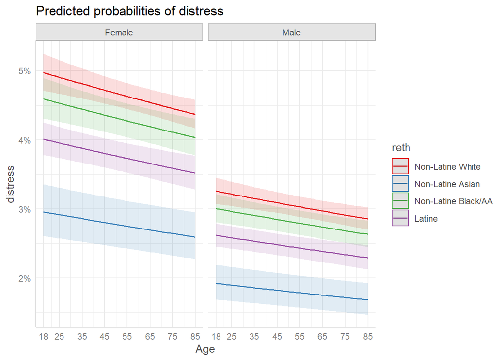

```r
ggpredict(model0b,
          terms = c("AGE[all]", "reth", "male")) %>%
  plot() + scale_x_continuous(limits=c(18,85),
                              breaks=c(18,25,35,45,55,65,75,85))
```

Notice that all line are parallel. This is because we only have main effects specified in the model. Each variable is held constant across all other variables. However, most times researchers are interested in interaction effects. For example, age could be moderating the association between sex assigned at birth and psychological distress. In this case, an interaction term needs to be specified in the model.

**Interactions with Logistic Regression**

The rest of the tutorial will involve fitting a series of logistic regression models with different types of interaction effects.

**Model 1: Continuous x Dichotomous Interaction**

One way to specify an interaction is with a “:”.

```r
model1 <- svyglm(distress ~ 1 + reth + AGE + educ1 + male + YEAR + AGE:male,
                design=des,
                family="quasibinomial")
summary(model1)
```

```
##
## Call:
## svyglm(formula = distress ~ 1 + reth + AGE + educ1 + male + YEAR +
##     AGE:male, design = des, family = "quasibinomial")
##
## Survey design:
## svydesign(ids = ~PSU, strata = ~STRATA, weights = ~SAMPWEIGHT,
##     nest = TRUE, data = data2)
##
## Coefficients:
##                           Estimate Std. Error t value Pr(>|t|)
## (Intercept)             -4.937e+01  3.722e+00 -13.265  < 2e-16 ***
## rethNon-Latine Asian    -5.392e-01  6.416e-02  -8.403  < 2e-16 ***
## rethNon-Latine Black/AA -8.509e-02  2.883e-02  -2.951  0.00322 **
## rethLatine              -2.250e-01  2.858e-02  -7.875 7.45e-15 ***
## AGE                     -3.977e-03  5.841e-04  -6.808 1.54e-11 ***
## educ1AA                 -3.546e-01  3.634e-02  -9.758  < 2e-16 ***
## educ1BA                 -1.105e+00  4.000e-02 -27.626  < 2e-16 ***
## educ1Below HS            5.920e-01  2.648e-02  22.359  < 2e-16 ***
## educ1More than BA       -1.382e+00  5.555e-02 -24.874  < 2e-16 ***
## educ1Some college       -2.290e-01  2.752e-02  -8.324 2.24e-16 ***
## maleMale                -6.856e-01  4.875e-02 -14.063  < 2e-16 ***
## YEAR                     2.317e-02  1.856e-03  12.484  < 2e-16 ***
## AGE:maleMale             5.328e-03  9.179e-04   5.804 8.21e-09 ***
## ---
## Signif. codes:  0 '***' 0.001 '**' 0.01 '*' 0.05 '.' 0.1 ' ' 1
##
## (Dispersion parameter for quasibinomial family taken to be 1.025949)
##
## Number of Fisher Scoring iterations: 7
```

We can retrieve the marginal effects in a similar way as above.

```r
marginal_effects_mod1 <- ggpredict(model1, terms = c("AGE[all]", "male"))
marginal_effects_mod1
```

```
## # Predicted probabilities of distress
##
## # male = Female
##
## AGE | Predicted |       95% CI
## ------------------------------
##  18 |      0.05 | [0.05, 0.06]
##  29 |      0.05 | [0.05, 0.05]
##  40 |      0.05 | [0.05, 0.05]
##  51 |      0.05 | [0.04, 0.05]
##  63 |      0.04 | [0.04, 0.05]
##  85 |      0.04 | [0.04, 0.04]
##
## # male = Male
##
## AGE | Predicted |       95% CI
## ------------------------------
##  18 |      0.03 | [0.03, 0.03]
##  29 |      0.03 | [0.03, 0.03]
##  40 |      0.03 | [0.03, 0.03]
##  51 |      0.03 | [0.03, 0.03]
##  63 |      0.03 | [0.03, 0.03]
##  85 |      0.03 | [0.03, 0.03]
##
## Adjusted for:
## *  reth = Non-Latine White
## * educ1 =           HS/GED
## *  YEAR =          2008.75
```

```
##
## Not all rows are shown in the ouput. Use `print(..., n = Inf)` to show
##   all rows.
```

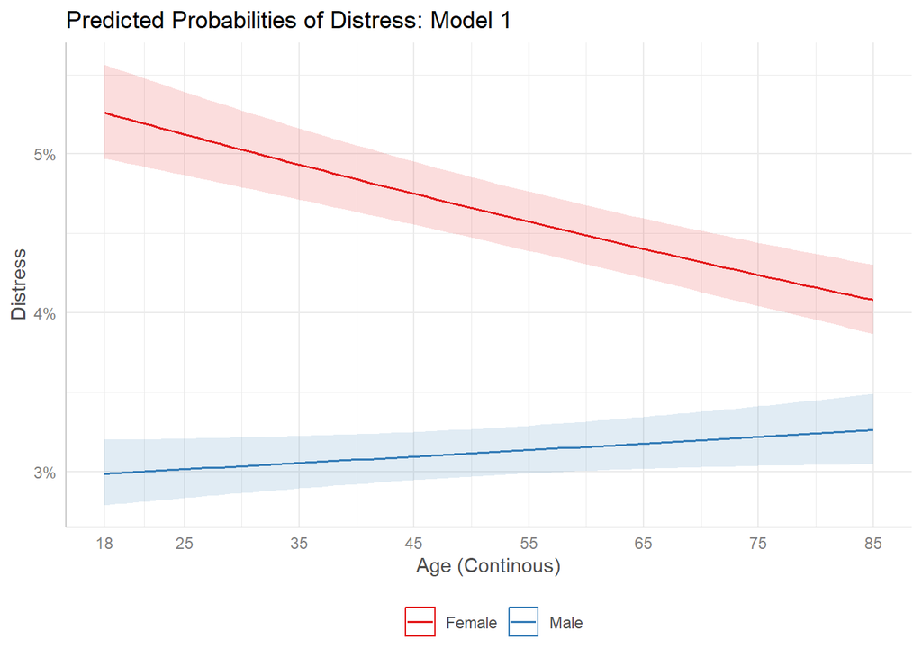

```r
plot(marginal_effects_mod1,
     facet = FALSE) +
   labs(title = "Predicted Probabilities of Distress: Model 1",
        x = "Age (Continous)",
        y = "Distress") +
  scale_x_continuous(limits=c(18,85),
                     breaks=c(18,25,35,45,55,65,75,85)) +
  theme(legend.position="bottom",
        legend.title = element_blank()) +
  guides(color=guide_legend(override.aes=list(fill=NA))) +
  theme(panel.spacing.x = unit(1.5, "lines"),panel.spacing.y=unit(1, "lines"))
```

**Figure #** Visualization of interaction effects for a continous measure of Age and Sex concerning having serious psychological distress.

Here, we can see that the slope of age on distress is different for females and males. In females, the predicted probability of experiencing distress decreases from 18 years of age (5%) to 85 years of age (4%). For the males, there is no change in distress across this age range (all probabilities are 3%).

We can also test whether these slopes are significantly different than 0 *AND* are significantly different from each other using the hypothesis_test() function.

```r
#Are there significant linear trends/ Are slopes different than 0?
hypothesis_test(model1, terms = c("AGE[all]", "male"), test = NULL)
```

```
## # Linear trend for AGE
##
## male   |     Slope |         95% CI |      p
## --------------------------------------------
## Female | -1.76e-04 | [ 0.00,  0.00] | < .001
## Male   |  4.09e-05 | [ 0.00,  0.00] | 0.078
```

```
##
## Slopes are presented as probabilities.
```

```r
#Do slopes between females and males differ from each other?
hypothesis_test(model1, terms = c("AGE[all]", "male"))
```

```
## # Linear trend for AGE
##
## male        |  Contrast |         95% CI |      p
## -------------------------------------------------
## Female-Male | -2.17e-04 | [ 0.00,  0.00] | < .001
```

```
##
## Contrasts are presented as probabilities.
```

For some data sets, it is possible we do not have enough observations to estimate reliable effects. Some researchers aggregate or collapse observations into categories or groups. This is usually guided by specific hypotheses or questions. In our case, we could be more interested in understanding whether risk varies based on a person being in mid-adulthood or older adulthood. Thus, we created a dichotomous variable to explore the interaction effect between Sex and this new variable.

**Model 2: Dichotomous x Dichotomous Interaction**

We re-specify model 1, but now replace AGE (out continous age variable) with agestage (our dichotomous age variable).

```r
model2<-svyglm(distress ~ 1 + reth + agestage + educ1 + male + YEAR + agestage:male,
               design=des,
               family="quasibinomial")
summary(model2)
```

```
##
## Call:
## svyglm(formula = distress ~ 1 + reth + agestage + educ1 + male +
##     YEAR + agestage:male, design = des, family = "quasibinomial")
##
## Survey design:
## svydesign(ids = ~PSU, strata = ~STRATA, weights = ~SAMPWEIGHT,
##     nest = TRUE, data = data2)
##
## Coefficients:
##                           Estimate Std. Error t value Pr(>|t|)
## (Intercept)             -52.776652   3.719692 -14.188  < 2e-16 ***
## rethNon-Latine Asian     -0.567048   0.064124  -8.843  < 2e-16 ***
## rethNon-Latine Black/AA  -0.117679   0.028780  -4.089 4.61e-05 ***
## rethLatine               -0.288942   0.028337 -10.197  < 2e-16 ***
## agestageOlder            -0.473335   0.028357 -16.692  < 2e-16 ***
## educ1AA                  -0.383750   0.036444 -10.530  < 2e-16 ***
## educ1BA                  -1.138944   0.040013 -28.464  < 2e-16 ***
## educ1Below HS             0.626121   0.026664  23.481  < 2e-16 ***
## educ1More than BA        -1.397983   0.055743 -25.079  < 2e-16 ***
## educ1Some college        -0.249223   0.027364  -9.108  < 2e-16 ***
## maleMale                 -0.487964   0.021479 -22.718  < 2e-16 ***
## YEAR                      0.024844   0.001854  13.403  < 2e-16 ***
## agestageOlder:maleMale    0.149073   0.044771   3.330 0.000895 ***
## ---
## Signif. codes:  0 '***' 0.001 '**' 0.01 '*' 0.05 '.' 0.1 ' ' 1
##
## (Dispersion parameter for quasibinomial family taken to be 1.032792)
##
## Number of Fisher Scoring iterations: 7
```

We can retrieve the marginal means in a similar way.

```r
#Marginal effects
marginal_effects_mod2 <- ggpredict(model2,
                                   terms = c("agestage", "male"))
marginal_effects_mod2
```

```
## # Predicted probabilities of distress
##
## # male = Female
##
## agestage | Predicted |       95% CI
## -----------------------------------
## Midage   |      0.05 | [0.05, 0.06]
## Older    |      0.03 | [0.03, 0.04]
##
## # male = Male
##
## agestage | Predicted |       95% CI
## -----------------------------------
## Midage   |      0.03 | [0.03, 0.04]
## Older    |      0.02 | [0.02, 0.03]
##
## Adjusted for:
## *  reth = Non-Latine White
## * educ1 =           HS/GED
## *  YEAR =          2008.75
```

And the code for the plot takes the object created from the ggeffects() function.

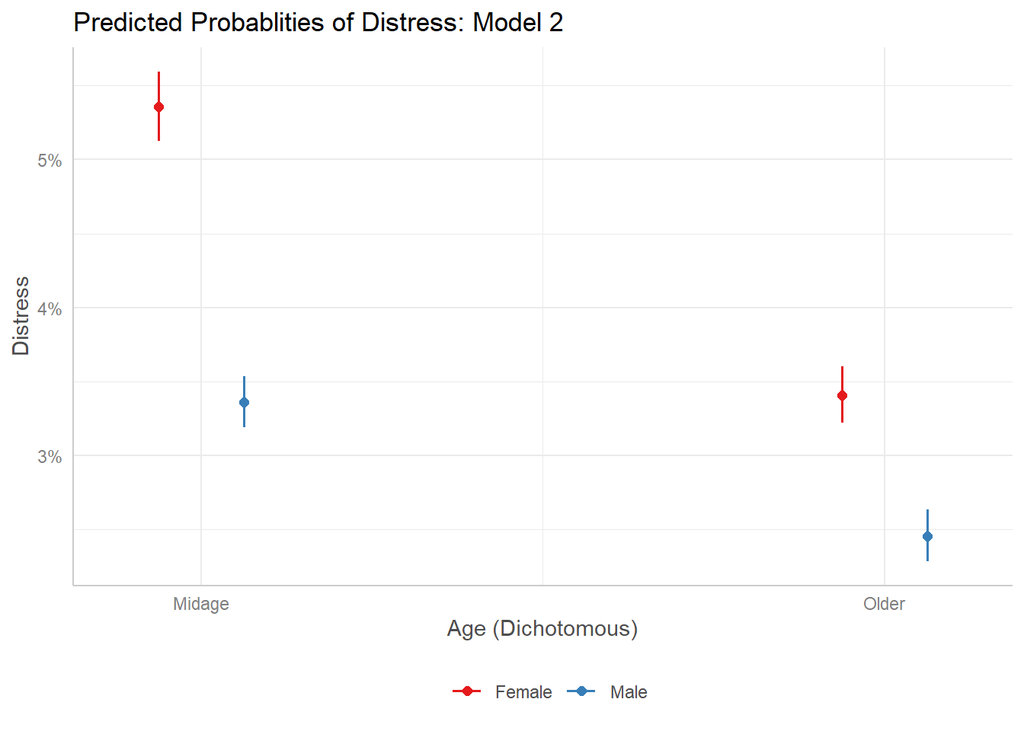

```r
#Plot code (more complex)
plot(marginal_effects_mod2,
     facet = FALSE) +
  labs(title = "Predicted Probablities of Distress: Model 2",
       x = "Age (Dichotomous)",
       y = "Distress") +
  #scale_x_continuous(limits=c(18,85),breaks=c(18,25,35,45,55,65,75,85))+
  theme(legend.position="bottom",legend.title = element_blank())+
  guides(color=guide_legend(override.aes=list(fill=NA)))+
  theme(panel.spacing.x=unit(1.5, "lines"),panel.spacing.y=unit(1, "lines"))
```

**Figure #** Visualization of interaction effects for a dichotomous measure of Age and sex concerning having serious psychological distress.

From this figure, the main effects are still clearly visible. Middle aged individuals have a higher predictive probability to report distress than older individuals, and females reported more distress than males. However, now terms are allowed to vary across these contrasts. For females (red dots), the predicted probability of reporting distress in middle aged participants is 5% and decreases to 3% in old age participants. For males (blue dots), the predicted probability of reporting distress decreases from 3% to 2% from middle to older aged participants. In other words, the predicted probability of reported distress decreases to a greater extent from middle-age to older age in females (decrase of 2%) compared to males (decrease of 1%).

The hypothesis_test() function can also be used to the significance of all pairwise comparisons.

```r
#Hypothesis test
hypothesis_test(model2, terms = c("agestage", "male"))
```

```
## # Pairwise comparisons
##
## agestage      |          male | Contrast |        95% CI |      p
## -----------------------------------------------------------------
## Midage-Older  | Female-Female |     0.02 | [ 0.02, 0.02] | < .001
## Midage-Midage |   Female-Male |     0.02 | [ 0.02, 0.02] | < .001
## Midage-Older  |   Female-Male |     0.03 | [ 0.03, 0.03] | < .001
## Older-Midage  |   Female-Male | 4.78e-04 | [ 0.00, 0.00] | 0.633
## Older-Older   |   Female-Male | 9.55e-03 | [ 0.01, 0.01] | < .001
## Midage-Older  |     Male-Male | 9.07e-03 | [ 0.01, 0.01] | < .001
```

```
##
## Contrasts are presented as probabilities.
```

```r
#Note that hypothesis_test(marginal_effects_mod2) is equivalent.
```

The only pairwise comparison that is not statistically significant are older-females (right side, red dot) and middle-aged-males (left side, blue dot).

**Model 3: Continuous x Categorical Interaction**

First, we fit the model and estimate the marginal effects.

```r
model3 <- svyglm(distress ~ 1 + reth + AGE + educ1 + male + YEAR + AGE:reth,
               design=des,
               family="quasibinomial")
summary(model3)
```

```
##
## Call:
## svyglm(formula = distress ~ 1 + reth + AGE + educ1 + male + YEAR +
##     AGE:reth, design = des, family = "quasibinomial")
##
## Survey design:
## svydesign(ids = ~PSU, strata = ~STRATA, weights = ~SAMPWEIGHT,
##     nest = TRUE, data = data2)
##
## Coefficients:
##                               Estimate Std. Error t value Pr(>|t|)
## (Intercept)                 -4.891e+01  3.720e+00 -13.147  < 2e-16 ***
## rethNon-Latine Asian        -1.030e+00  1.686e-01  -6.108 1.35e-09 ***
## rethNon-Latine Black/AA     -1.981e-01  6.760e-02  -2.931 0.003445 **
## rethLatine                  -9.908e-01  6.403e-02 -15.475  < 2e-16 ***
## AGE                         -5.010e-03  5.559e-04  -9.013  < 2e-16 ***
## educ1AA                     -3.580e-01  3.627e-02  -9.872  < 2e-16 ***
## educ1BA                     -1.110e+00  4.006e-02 -27.703  < 2e-16 ***
## educ1Below HS                5.801e-01  2.672e-02  21.711  < 2e-16 ***
## educ1More than BA           -1.374e+00  5.555e-02 -24.739  < 2e-16 ***
## educ1Some college           -2.321e-01  2.754e-02  -8.425  < 2e-16 ***
## maleMale                    -4.400e-01  1.961e-02 -22.442  < 2e-16 ***
## YEAR                         2.297e-02  1.855e-03  12.381  < 2e-16 ***
## rethNon-Latine Asian:AGE     1.058e-02  3.187e-03   3.321 0.000925 ***
## rethNon-Latine Black/AA:AGE  2.358e-03  1.277e-03   1.846 0.065077 .
## rethLatine:AGE               1.776e-02  1.224e-03  14.514  < 2e-16 ***
## ---
## Signif. codes:  0 '***' 0.001 '**' 0.01 '*' 0.05 '.' 0.1 ' ' 1
##
## (Dispersion parameter for quasibinomial family taken to be 1.02616)
##
## Number of Fisher Scoring iterations: 7
```

```r
#Marginal effects
marginal_effects_mod3 <- ggpredict(model3,
                                   terms = c("AGE[all]", "reth"))
marginal_effects_mod3
```

```
## # Predicted probabilities of distress
##
## # reth = Non-Latine White
##
## AGE | Predicted |       95% CI
## ------------------------------
##  18 |      0.05 | [0.05, 0.06]
##  31 |      0.05 | [0.05, 0.05]
##  45 |      0.05 | [0.05, 0.05]
##  58 |      0.04 | [0.04, 0.05]
##  85 |      0.04 | [0.04, 0.04]
##
## # reth = Non-Latine Asian
##
## AGE | Predicted |       95% CI
## ------------------------------
##  18 |      0.02 | [0.02, 0.03]
##  31 |      0.03 | [0.02, 0.03]
##  45 |      0.03 | [0.02, 0.03]
##  58 |      0.03 | [0.03, 0.03]
##  85 |      0.03 | [0.03, 0.04]
##
## # reth = Non-Latine Black/AA
##
## AGE | Predicted |       95% CI
## ------------------------------
##  18 |      0.05 | [0.04, 0.05]
##  31 |      0.05 | [0.04, 0.05]
##  45 |      0.04 | [0.04, 0.05]
##  58 |      0.04 | [0.04, 0.05]
##  85 |      0.04 | [0.04, 0.04]
##
## # reth = Latine
##
## AGE | Predicted |       95% CI
## ------------------------------
##  18 |      0.03 | [0.03, 0.03]
##  31 |      0.03 | [0.03, 0.04]
##  45 |      0.04 | [0.04, 0.04]
##  58 |      0.05 | [0.04, 0.05]
##  85 |      0.06 | [0.06, 0.07]
##
## Adjusted for:
## * educ1 =  HS/GED
## *  male =  Female
## *  YEAR = 2008.75
```

```
##
## Not all rows are shown in the ouput. Use `print(..., n = Inf)` to show
##   all rows.
```

And plot the marginal effects.

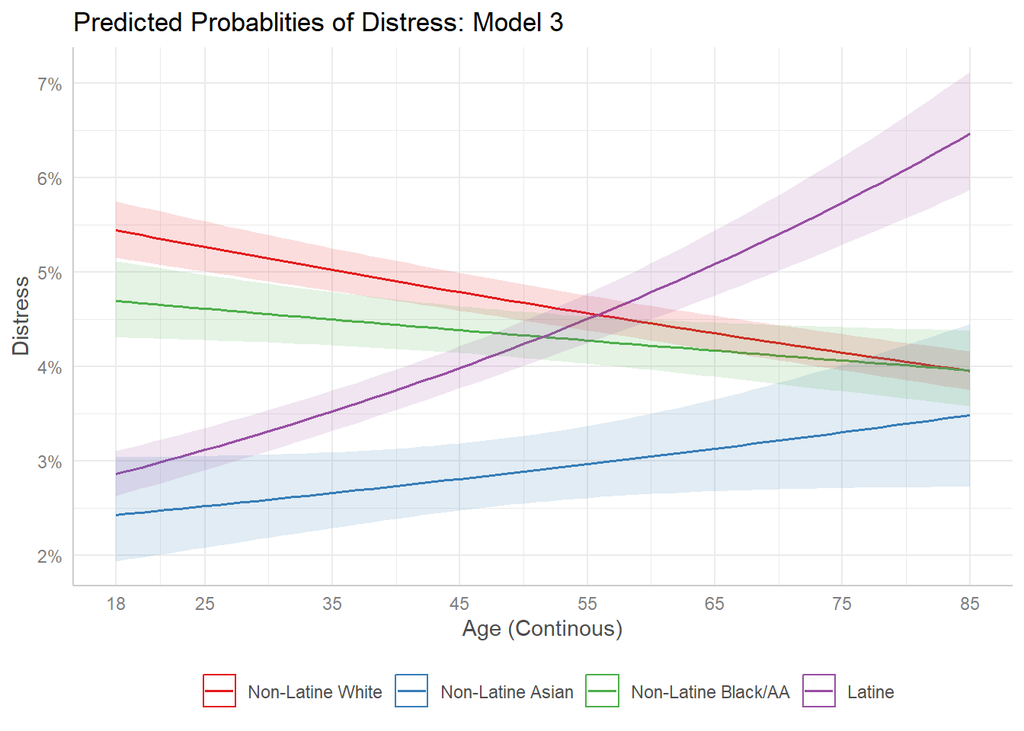

```r
#Plot code
plot(marginal_effects_mod3,
     facet = FALSE) +
  labs(title = "Predicted Probablities of Distress: Model 3",
       x = "Age (Continous)",
       y = "Distress") +
  scale_x_continuous(limits=c(18,85),breaks=c(18,25,35,45,55,65,75,85))+
  theme(legend.position="bottom",legend.title = element_blank())+
  guides(color=guide_legend(override.aes=list(fill=NA)))+
  theme(panel.spacing.x=unit(1.5, "lines"),panel.spacing.y=unit(1, "lines"))
```

**Figure #** Visualization of interaction effects for a continuous measure of Age and ethnicity concerning having serious psychological distress.

We can also look at whether any slopes are different than 0, and whether there are any significant differences in slopes between ethnicity groups.

```r
#Are there significant linear trends/ Are slopes different than 0?
hypothesis_test(marginal_effects_mod3, test = NULL)
```

```
## # Linear trend for AGE
##
## reth                |     Slope |         95% CI |      p
## ---------------------------------------------------------
## Non-Latine White    | -2.22e-04 | [ 0.00,  0.00] | < .001
## Non-Latine Asian    |  1.58e-04 | [ 0.00,  0.00] | 0.084
## Non-Latine Black/AA | -1.10e-04 | [ 0.00,  0.00] | 0.025
## Latine              |  5.39e-04 | [ 0.00,  0.00] | < .001
```

```
##
## Slopes are presented as probabilities.
```

```r
#Do slopes between females and males differ from each other?
hypothesis_test(marginal_effects_mod3)
```

```
## # Linear trend for AGE
##
## reth                                   |  Contrast |         95% CI |      p
## ----------------------------------------------------------------------------
## (Non-LatineWhite)-(Non-LatineAsian)    | -3.81e-04 | [ 0.00,  0.00] | < .001
## (Non-LatineWhite)-(Non-LatineBlack/AA) | -1.13e-04 | [ 0.00,  0.00] | 0.034
## (Non-LatineWhite)-(Latine)             | -7.61e-04 | [ 0.00,  0.00] | < .001
## (Non-LatineAsian)-(Non-LatineBlack/AA) |  2.68e-04 | [ 0.00,  0.00] | 0.009
## (Non-LatineAsian)-(Latine)             | -3.81e-04 | [ 0.00,  0.00] | < .001
## (Non-LatineBlack/AA)-(Latine)          | -6.49e-04 | [ 0.00,  0.00] | < .001
```

```
##
## Contrasts are presented as probabilities.
```

Finally, when there are categorical variables, a researcher could be interested in testing a “differences in differences” hypothesis. For example, “Does the difference of the slopes of age between White and Asian individuals (difference in red and blue lines) are different from the slope-difference for the groups White and Latine individuals (difference in red and purple lines)?”

```r
hypothesis_test(model3, terms = c("AGE[all]", "reth"), test = "(b1 - b2) = (b1 - b4)")
```

```
## Hypothesis      | Contrast |       95% CI |      p
## --------------------------------------------------
## (b1-b2)=(b1-b4) | 3.81e-04 | [0.00, 0.00] | < .001
##
## Tested hypothesis: (reth[Non-Latine White] - reth[Non-Latine Asian]) =
##   (reth[Non-Latine White] - reth[Latine])
```

```
## Contrasts are presented as probabilities.
```

We see that there is a significant difference in differences between the slopes of White and Asian individuals and White and Latine individuals.

**Model 4: Dichotomous x Categorical Interaction**

We can do a similar exercise, but use our dichotomous age variable.

```r
model4 <- svyglm(distress ~ 1 + reth + agestage + educ1 + male + YEAR + agestage:reth,
               design=des,
               family="quasibinomial")
summary(model4)
```

```
##
## Call:
## svyglm(formula = distress ~ 1 + reth + agestage + educ1 + male +
##     YEAR + agestage:reth, design = des, family = "quasibinomial")
##
## Survey design:
## svydesign(ids = ~PSU, strata = ~STRATA, weights = ~SAMPWEIGHT,
##     nest = TRUE, data = data2)
##
## Coefficients:
##                                         Estimate Std. Error t value Pr(>|t|)
## (Intercept)                           -52.784521   3.714249 -14.211  < 2e-16
## rethNon-Latine Asian                   -0.695009   0.076343  -9.104  < 2e-16
## rethNon-Latine Black/AA                -0.118058   0.031666  -3.728 0.000202
## rethLatine                             -0.401578   0.030940 -12.979  < 2e-16
## agestageOlder                          -0.523074   0.026567 -19.689  < 2e-16
## educ1AA                                -0.387373   0.036471 -10.621  < 2e-16
## educ1BA                                -1.142975   0.040084 -28.515  < 2e-16
## educ1Below HS                           0.623261   0.026864  23.200  < 2e-16
## educ1More than BA                      -1.394542   0.055742 -25.018  < 2e-16
## educ1Some college                      -0.250899   0.027385  -9.162  < 2e-16
## maleMale                               -0.457991   0.019651 -23.306  < 2e-16
## YEAR                                    0.024854   0.001851  13.428  < 2e-16
## rethNon-Latine Asian:agestageOlder      0.607547   0.131629   4.616 4.33e-06
## rethNon-Latine Black/AA:agestageOlder  -0.040491   0.068005  -0.595 0.551676
## rethLatine:agestageOlder                0.728929   0.056185  12.974  < 2e-16
##
## (Intercept)                           ***
## rethNon-Latine Asian                  ***
## rethNon-Latine Black/AA               ***
## rethLatine                            ***
## agestageOlder                         ***
## educ1AA                               ***
## educ1BA                               ***
## educ1Below HS                         ***
## educ1More than BA                     ***
## educ1Some college                     ***
## maleMale                              ***
## YEAR                                  ***
## rethNon-Latine Asian:agestageOlder    ***
## rethNon-Latine Black/AA:agestageOlder
## rethLatine:agestageOlder              ***
## ---
## Signif. codes:  0 '***' 0.001 '**' 0.01 '*' 0.05 '.' 0.1 ' ' 1
##
## (Dispersion parameter for quasibinomial family taken to be 1.035428)
##
## Number of Fisher Scoring iterations: 7
```

```r
#Marginal effects
marginal_effects_mod4 <- ggpredict(model4, terms = c("agestage", "reth"))
marginal_effects_mod4
```

```
## # Predicted probabilities of distress
##
## # reth = Non-Latine White
##
## agestage | Predicted |       95% CI
## -----------------------------------
## Midage   |      0.05 | [0.05, 0.06]
## Older    |      0.03 | [0.03, 0.03]
##
## # reth = Non-Latine Asian
##
## agestage | Predicted |       95% CI
## -----------------------------------
## Midage   |      0.03 | [0.02, 0.03]
## Older    |      0.03 | [0.02, 0.04]
##
## # reth = Non-Latine Black/AA
##
## agestage | Predicted |       95% CI
## -----------------------------------
## Midage   |      0.05 | [0.05, 0.05]
## Older    |      0.03 | [0.03, 0.03]
##
## # reth = Latine
##
## agestage | Predicted |       95% CI
## -----------------------------------
## Midage   |      0.04 | [0.03, 0.04]
## Older    |      0.05 | [0.04, 0.05]
##
## Adjusted for:
## * educ1 =  HS/GED
## *  male =  Female
## *  YEAR = 2008.75
```

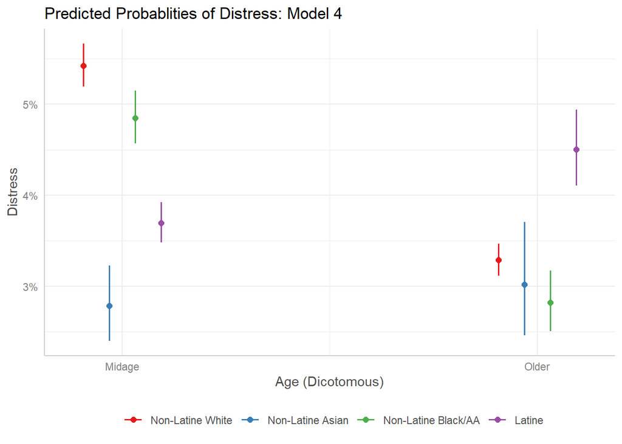

```r
#Plot code
plot(marginal_effects_mod4,
     facet = FALSE) +
  labs(title = "Predicted Probablities of Distress: Model 4",
       x = "Age (Dicotomous)",
       y = "Distress") +
  #scale_x_continuous(limits=c(18,85),breaks=c(18,25,35,45,55,65,75,85))+
  theme(legend.position="bottom",legend.title = element_blank())+
  guides(color=guide_legend(override.aes=list(fill=NA)))+
  theme(panel.spacing.x=unit(1.5, "lines"),panel.spacing.y=unit(1, "lines"))
```

**Figure #** Visualization of interaction effects for a dichotomous measure of Age and ethnicity concerning having serious psychological distress.

From the plot and marginal effects tables, we can see that ethnicity is moderating the associating between age and distress. For White individuals, there is a 5% probability of reporting distress during middle age and a 3% probability of reporting distress during older age. For Asian individuals, there is a 3% probability of reporting distress during middle age and older age. For Black individuals, there is a 5% probability of reporting distress during middle age and a 3% probability of reporting distress during older age. Finally, for Latine individuals, there is a 4% probability of reporting distress during middle age and a 5% probability of reporting distress during older age.

For both models 3 and 4, the take home message is that for Latine individuals, there is increased risk in reporting psychological distress during older age compared to middle age.

We can also see whether any pairwise comparrisons among these groups are significant.

```r
#Hypothesis test
hypothesis_test(marginal_effects_mod4)
```

```
## # Pairwise comparisons
##
## agestage      |                                    reth |  Contrast |         95% CI |      p
## ---------------------------------------------------------------------------------------------
## Midage-Older  |       Non-Latine White-Non-Latine White |      0.02 | [ 0.02,  0.02] | < .001
## Midage-Midage |       Non-Latine White-Non-Latine Asian |      0.03 | [ 0.02,  0.03] | < .001
## Midage-Older  |       Non-Latine White-Non-Latine Asian |      0.02 | [ 0.02,  0.03] | < .001
## Midage-Midage |    Non-Latine White-Non-Latine Black/AA |  5.75e-03 | [ 0.00,  0.01] | < .001
## Midage-Older  |    Non-Latine White-Non-Latine Black/AA |      0.03 | [ 0.02,  0.03] | < .001
## Midage-Midage |                 Non-Latine White-Latine |      0.02 | [ 0.01,  0.02] | < .001
## Midage-Older  |                 Non-Latine White-Latine |  9.21e-03 | [ 0.00,  0.01] | < .001
## Older-Midage  |       Non-Latine White-Non-Latine Asian |  5.05e-03 | [ 0.00,  0.01] | 0.021
## Older-Older   |       Non-Latine White-Non-Latine Asian |  2.67e-03 | [ 0.00,  0.01] | 0.407
## Older-Midage  |    Non-Latine White-Non-Latine Black/AA |     -0.02 | [-0.02, -0.01] | < .001
## Older-Older   |    Non-Latine White-Non-Latine Black/AA |  4.68e-03 | [ 0.00,  0.01] | 0.007
## Older-Midage  |                 Non-Latine White-Latine | -4.09e-03 | [-0.01,  0.00] | < .001
## Older-Older   |                 Non-Latine White-Latine |     -0.01 | [-0.02, -0.01] | < .001
## Midage-Older  |       Non-Latine Asian-Non-Latine Asian | -2.38e-03 | [-0.01,  0.00] | 0.521
## Midage-Midage |    Non-Latine Asian-Non-Latine Black/AA |     -0.02 | [-0.03, -0.02] | < .001
## Midage-Older  |    Non-Latine Asian-Non-Latine Black/AA | -3.64e-04 | [-0.01,  0.00] | 0.885
## Midage-Midage |                 Non-Latine Asian-Latine | -9.14e-03 | [-0.01,  0.00] | < .001
## Midage-Older  |                 Non-Latine Asian-Latine |     -0.02 | [-0.02, -0.01] | < .001
## Older-Midage  |    Non-Latine Asian-Non-Latine Black/AA |     -0.02 | [-0.03, -0.01] | < .001
## Older-Older   |    Non-Latine Asian-Non-Latine Black/AA |  2.01e-03 | [-0.01,  0.01] | 0.574
## Older-Midage  |                 Non-Latine Asian-Latine | -6.76e-03 | [-0.01,  0.00] | 0.039
## Older-Older   |                 Non-Latine Asian-Latine |     -0.01 | [-0.02, -0.01] | < .001
## Midage-Older  | Non-Latine Black/AA-Non-Latine Black/AA |      0.02 | [ 0.02,  0.02] | < .001
## Midage-Midage |              Non-Latine Black/AA-Latine |      0.01 | [ 0.01,  0.01] | < .001
## Midage-Older  |              Non-Latine Black/AA-Latine |  3.46e-03 | [ 0.00,  0.01] | 0.139
## Older-Midage  |              Non-Latine Black/AA-Latine | -8.78e-03 | [-0.01, -0.01] | < .001
## Older-Older   |              Non-Latine Black/AA-Latine |     -0.02 | [-0.02, -0.01] | < .001
## Midage-Older  |                           Latine-Latine | -8.07e-03 | [-0.01,  0.00] | < .001
```

```
##
## Contrasts are presented as probabilities.
```

**Model 5: Continous x Dichotomous x Categorical Interaction**

For instances where we want to explore whether three variables operate together concerning our outcome we rely on three-way interactions. These can be interpreted as the examination of whether an effect varies at the intersection of these three variables. In this case, the interaction between age, race and ethnicity, and sex concerning serious psychological distress.

Fitting a three-way interaction model is done in a similar way as a two-way interaction. But now, we specify the interaction use a *. This tests for all possible two-way interactions, as well as the three-way interaction.

```r
model5 <- svyglm(distress ~ 1 + reth + AGE + educ1 + male + YEAR + AGE*reth*male,
               design = des,
               family = "quasibinomial")
summary(model5)
```

```
##
## Call:
## svyglm(formula = distress ~ 1 + reth + AGE + educ1 + male + YEAR +
##     AGE * reth * male, design = des, family = "quasibinomial")
##
## Survey design:
## svydesign(ids = ~PSU, strata = ~STRATA, weights = ~SAMPWEIGHT,
##     nest = TRUE, data = data2)
##
## Coefficients:
##                                        Estimate Std. Error t value Pr(>|t|)
## (Intercept)                          -4.878e+01  3.721e+00 -13.111  < 2e-16 ***
## rethNon-Latine Asian                 -1.335e+00  2.276e-01  -5.865 5.78e-09 ***
## rethNon-Latine Black/AA              -2.243e-01  8.116e-02  -2.764 0.005804 **
## rethLatine                           -9.642e-01  7.595e-02 -12.696  < 2e-16 ***
## AGE                                  -7.193e-03  6.965e-04 -10.327  < 2e-16 ***
## educ1AA                              -3.618e-01  3.631e-02  -9.964  < 2e-16 ***
## educ1BA                              -1.117e+00  4.003e-02 -27.893  < 2e-16 ***
## educ1Below HS                         5.789e-01  2.672e-02  21.664  < 2e-16 ***
## educ1More than BA                    -1.385e+00  5.556e-02 -24.926  < 2e-16 ***
## educ1Some college                    -2.361e-01  2.756e-02  -8.567  < 2e-16 ***
## maleMale                             -6.850e-01  5.993e-02 -11.429  < 2e-16 ***
## YEAR                                  2.295e-02  1.856e-03  12.367  < 2e-16 ***
## rethNon-Latine Asian:AGE              1.609e-02  4.258e-03   3.779 0.000165 ***
## rethNon-Latine Black/AA:AGE           2.991e-03  1.592e-03   1.878 0.060608 .
## rethLatine:AGE                        1.881e-02  1.469e-03  12.803  < 2e-16 ***
## AGE:maleMale                          5.984e-03  1.106e-03   5.409 7.63e-08 ***
## rethNon-Latine Asian:maleMale         7.733e-01  3.335e-01   2.318 0.020591 *
## rethNon-Latine Black/AA:maleMale      5.810e-02  1.472e-01   0.395 0.693136
## rethLatine:maleMale                  -3.379e-02  1.299e-01  -0.260 0.794859
## rethNon-Latine Asian:AGE:maleMale    -1.430e-02  6.345e-03  -2.254 0.024358 *
## rethNon-Latine Black/AA:AGE:maleMale -1.476e-03  2.804e-03  -0.526 0.598681
## rethLatine:AGE:maleMale              -3.623e-03  2.527e-03  -1.434 0.151858
## ---
## Signif. codes:  0 '***' 0.001 '**' 0.01 '*' 0.05 '.' 0.1 ' ' 1
##
## (Dispersion parameter for quasibinomial family taken to be 1.025258)
##
## Number of Fisher Scoring iterations: 7
```

```r
#Marginal effects
marginal_effects_mod5 <- ggpredict(model5,
                                   terms = c("AGE[all]", "reth", "male"))
marginal_effects_mod5
```

```
## # Predicted probabilities of distress
##
## # reth = Non-Latine White
## # male = Female
##
## AGE | Predicted |       95% CI
## ------------------------------
##  18 |      0.06 | [0.05, 0.06]
##  35 |      0.05 | [0.05, 0.05]
##  51 |      0.05 | [0.04, 0.05]
##  85 |      0.04 | [0.03, 0.04]
##
## # reth = Non-Latine Asian
## # male = Female
##
## AGE | Predicted |       95% CI
## ------------------------------
##  18 |      0.02 | [0.02, 0.03]
##  35 |      0.02 | [0.02, 0.03]
##  51 |      0.03 | [0.02, 0.03]
##  85 |      0.04 | [0.03, 0.05]
##
## # reth = Non-Latine Black/AA
## # male = Female
##
## AGE | Predicted |       95% CI
## ------------------------------
##  18 |      0.05 | [0.04, 0.05]
##  35 |      0.05 | [0.04, 0.05]
##  51 |      0.04 | [0.04, 0.05]
##  85 |      0.04 | [0.03, 0.04]
##
## # reth = Latine
## # male = Female
##
## AGE | Predicted |       95% CI
## ------------------------------
##  18 |      0.03 | [0.03, 0.03]
##  35 |      0.04 | [0.04, 0.04]
##  51 |      0.05 | [0.04, 0.05]
```

[output cut: 30 more lines]

```
##  85 |      0.03 | [0.02, 0.03]
##
## # reth = Latine
## # male = Male
##
## AGE | Predicted |       95% CI
## ------------------------------
##  18 |      0.02 | [0.01, 0.02]
##  35 |      0.02 | [0.02, 0.02]
##  51 |      0.03 | [0.02, 0.03]
##  85 |      0.04 | [0.03, 0.05]
##
## Adjusted for:
## * educ1 =  HS/GED
## *  YEAR = 2008.75
```

```
##
## Not all rows are shown in the ouput. Use `print(..., n = Inf)` to show
##   all rows.
```

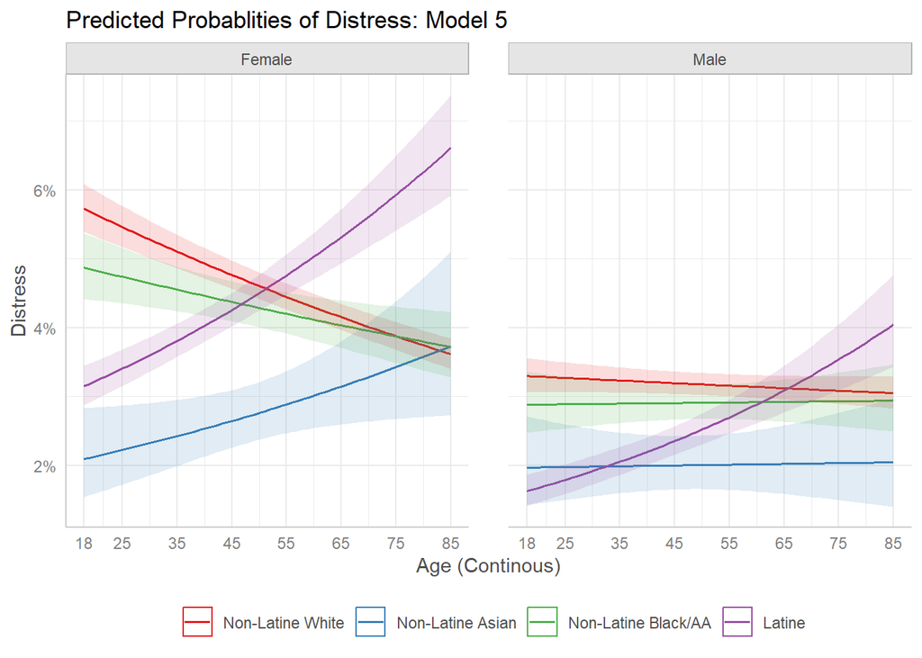

```r
#Plot code
plot(marginal_effects_mod5,
     facet = TRUE) +
  labs(title = "Predicted Probablities of Distress: Model 5",
       x = "Age (Continous)",
       y = "Distress") +
  scale_x_continuous(limits=c(18,85),breaks=c(18,25,35,45,55,65,75,85))+
  theme(legend.position="bottom",legend.title = element_blank())+
  guides(color=guide_legend(override.aes=list(fill=NA)))+
  theme(panel.spacing.x=unit(1.5, "lines"),panel.spacing.y=unit(1, "lines"))
```

From this figure we can observe that the associations between race and ethnicity vary by age mostly for female respondents. Among male respondents, the only visible age gradient was found for Latine adults.

We can test for significant using the hypothesis_test() function.

```r
#Are there significant linear trends/ Are slopes different than 0?
hypothesis_test(marginal_effects_mod5, test = NULL)
```

```
## # Linear trend for AGE
##
## reth                |   male |     Slope |         95% CI |      p
## ------------------------------------------------------------------
## Non-Latine White    | Female | -3.15e-04 | [ 0.00,  0.00] | < .001
## Non-Latine White    |   Male | -3.72e-05 | [ 0.00,  0.00] | 0.171
## Non-Latine Asian    | Female |  2.45e-04 | [ 0.00,  0.00] | 0.044
## Non-Latine Asian    |   Male |  1.14e-05 | [ 0.00,  0.00] | 0.898
## Non-Latine Black/AA | Female | -1.72e-04 | [ 0.00,  0.00] | 0.003
## Non-Latine Black/AA |   Male |  8.61e-06 | [ 0.00,  0.00] | 0.885
## Latine              | Female |  5.17e-04 | [ 0.00,  0.00] | < .001
## Latine              |   Male |  3.61e-04 | [ 0.00,  0.00] | < .001
```

```
##
## Slopes are presented as probabilities.
```

```r
#Do slopes between females and males differ from each other?
hypothesis_test(marginal_effects_mod5)
```

```
## # Linear trend for AGE
##
## reth                                      |            male |  Contrast |         95% CI |      p
## -------------------------------------------------------------------------------------------------
## (Non-Latine White-(Non-Latine White       |   Female)-Male) | -2.78e-04 | [ 0.00,  0.00] | < .001
## (Non-Latine White-(Non-Latine Asian       | Female)-Female) | -5.60e-04 | [ 0.00,  0.00] | < .001
## (Non-Latine White-(Non-Latine Asian       |   Female)-Male) | -3.27e-04 | [ 0.00,  0.00] | < .001
## (Non-Latine White-(Non-Latine Black/AA    | Female)-Female) | -1.43e-04 | [ 0.00,  0.00] | 0.029
## (Non-Latine White-(Non-Latine Black/AA    |   Female)-Male) | -3.24e-04 | [ 0.00,  0.00] | < .001
## (Non-Latine White-(Latine                 | Female)-Female) | -8.32e-04 | [ 0.00,  0.00] | < .001
## (Non-Latine White-(Latine                 |   Female)-Male) | -6.77e-04 | [ 0.00,  0.00] | < .001
## (Non-Latine White-(Non-Latine Asian       |   Male)-Female) | -2.82e-04 | [ 0.00,  0.00] | 0.025
## (Non-Latine White-(Non-Latine Asian       |     Male)-Male) | -4.85e-05 | [ 0.00,  0.00] | 0.605
## (Non-Latine White-(Non-Latine Black/AA    |   Male)-Female) |  1.35e-04 | [ 0.00,  0.00] | 0.035
## (Non-Latine White-(Non-Latine Black/AA    |     Male)-Male) | -4.58e-05 | [ 0.00,  0.00] | 0.478
## (Non-Latine White-(Latine                 |   Male)-Female) | -5.54e-04 | [ 0.00,  0.00] | < .001
## (Non-Latine White-(Latine                 |     Male)-Male) | -3.99e-04 | [ 0.00,  0.00] | < .001
## (Non-Latine Asian-(Non-Latine Asian       |   Female)-Male) |  2.34e-04 | [ 0.00,  0.00] | 0.125
## (Non-Latine Asian-(Non-Latine Black/AA    | Female)-Female) |  4.17e-04 | [ 0.00,  0.00] | 0.002
## (Non-Latine Asian-(Non-Latine Black/AA    |   Female)-Male) |  2.36e-04 | [ 0.00,  0.00] | 0.078
## (Non-Latine Asian-(Latine                 | Female)-Female) | -2.72e-04 | [ 0.00,  0.00] | 0.051
## (Non-Latine Asian-(Latine                 |   Female)-Male) | -1.16e-04 | [ 0.00,  0.00] | 0.388
## (Non-Latine Asian-(Non-Latine Black/AA    |   Male)-Female) |  1.83e-04 | [ 0.00,  0.00] | 0.081
## (Non-Latine Asian-(Non-Latine Black/AA    |     Male)-Male) |  2.78e-06 | [ 0.00,  0.00] | 0.979
## (Non-Latine Asian-(Latine                 |   Male)-Female) | -5.06e-04 | [ 0.00,  0.00] | < .001
## (Non-Latine Asian-(Latine                 |     Male)-Male) | -3.50e-04 | [ 0.00,  0.00] | 0.001
## (Non-Latine Black/AA-(Non-Latine Black/AA |   Female)-Male) | -1.80e-04 | [ 0.00,  0.00] | 0.032
## (Non-Latine Black/AA-(Latine              | Female)-Female) | -6.89e-04 | [ 0.00,  0.00] | < .001
## (Non-Latine Black/AA-(Latine              |   Female)-Male) | -5.33e-04 | [ 0.00,  0.00] | < .001
## (Non-Latine Black/AA-(Latine              |   Male)-Female) | -5.08e-04 | [ 0.00,  0.00] | < .001
## (Non-Latine Black/AA-(Latine              |     Male)-Male) | -3.53e-04 | [ 0.00,  0.00] | < .001
## (Latine-(Latine                           |   Female)-Male) |  1.56e-04 | [ 0.00,  0.00] | 0.069
```

```
##
## Contrasts are presented as probabilities.
```

For fun, we can also look at “differences in differences” between some of these groups.

```r
hypothesis_test(marginal_effects_mod5, test = "(b1 - b2) = (b1 - b4)")
```

```
## Hypothesis      | Contrast |        95% CI |     p
## --------------------------------------------------
## (b1-b2)=(b1-b4) | 4.85e-05 | [ 0.00, 0.00] | 0.605
##
## Tested hypothesis: (reth[Non-Latine White],male[Female] -
##   reth[Non-Latine White],male[Male]) = (reth[Non-Latine
##   White],male[Female] - reth[Non-Latine Asian],male[Male])
```

```
## Contrasts are presented as probabilities.
```

This example show that the difference of slopes between White Females and White Males (red lines) is not significantly different than the difference of slopes between White Females and Asian Males.

**Model 6: Dichotomous x Dichotomous x Categorical Interaction**

```r
model6 <- svyglm(distress ~ 1 + reth + agestage + educ1 + male + YEAR + agestage*reth*male,
               design=des,
               family="quasibinomial")
summary(model6)
```

```
##
## Call:
## svyglm(formula = distress ~ 1 + reth + agestage + educ1 + male +
##     YEAR + agestage * reth * male, design = des, family = "quasibinomial")
##
## Survey design:
## svydesign(ids = ~PSU, strata = ~STRATA, weights = ~SAMPWEIGHT,
##     nest = TRUE, data = data2)
##
## Coefficients:
##                                                  Estimate Std. Error t value
## (Intercept)                                    -5.273e+01  3.716e+00 -14.188
## rethNon-Latine Asian                           -8.058e-01  9.810e-02  -8.214
## rethNon-Latine Black/AA                        -1.186e-01  3.805e-02  -3.117
## rethLatine                                     -3.194e-01  3.508e-02  -9.103
## agestageOlder                                  -5.802e-01  3.327e-02 -17.437
## educ1AA                                        -3.892e-01  3.643e-02 -10.683
## educ1BA                                        -1.146e+00  4.007e-02 -28.605
## educ1Below HS                                   6.226e-01  2.686e-02  23.179
## educ1More than BA                              -1.400e+00  5.577e-02 -25.110
## educ1Some college                              -2.529e-01  2.739e-02  -9.234
## maleMale                                       -4.569e-01  2.627e-02 -17.395
## YEAR                                            2.483e-02  1.852e-03  13.405
## rethNon-Latine Asian:agestageOlder              8.554e-01  1.596e-01   5.359
## rethNon-Latine Black/AA:agestageOlder          -8.958e-03  8.242e-02  -0.109
## rethLatine:agestageOlder                        7.136e-01  7.029e-02  10.153
## agestageOlder:maleMale                          1.636e-01  5.255e-02   3.114
## rethNon-Latine Asian:maleMale                   2.786e-01  1.451e-01   1.920
## rethNon-Latine Black/AA:maleMale                8.692e-04  6.496e-02   0.013
## rethLatine:maleMale                            -2.096e-01  5.887e-02  -3.560
## rethNon-Latine Asian:agestageOlder:maleMale    -7.351e-01  2.917e-01  -2.520
## rethNon-Latine Black/AA:agestageOlder:maleMale -8.469e-02  1.377e-01  -0.615
## rethLatine:agestageOlder:maleMale               1.561e-02  1.238e-01   0.126
##                                                Pr(>|t|)
## (Intercept)                                     < 2e-16 ***
## rethNon-Latine Asian                           5.37e-16 ***
## rethNon-Latine Black/AA                        0.001868 **
## rethLatine                                      < 2e-16 ***
## agestageOlder                                   < 2e-16 ***
## educ1AA                                         < 2e-16 ***
## educ1BA                                         < 2e-16 ***
## educ1Below HS                                   < 2e-16 ***
## educ1More than BA                               < 2e-16 ***
## educ1Some college                               < 2e-16 ***
## maleMale                                        < 2e-16 ***
## YEAR                                            < 2e-16 ***
## rethNon-Latine Asian:agestageOlder             1.00e-07 ***
## rethNon-Latine Black/AA:agestageOlder          0.913475
## rethLatine:agestageOlder                        < 2e-16 ***
## agestageOlder:maleMale                         0.001890 **
## rethNon-Latine Asian:maleMale                  0.055098 .
## rethNon-Latine Black/AA:maleMale               0.989327
## rethLatine:maleMale                            0.000384 ***
## rethNon-Latine Asian:agestageOlder:maleMale    0.011858 *
## rethNon-Latine Black/AA:agestageOlder:maleMale 0.538717
## rethLatine:agestageOlder:maleMale              0.899633
## ---
## Signif. codes:  0 '***' 0.001 '**' 0.01 '*' 0.05 '.' 0.1 ' ' 1
##
## (Dispersion parameter for quasibinomial family taken to be 1.033584)
##
## Number of Fisher Scoring iterations: 7
```

```r
#Marginal effects
marginal_effects_mod6 <- ggpredict(model6, terms = c("agestage", "reth", "male"))
marginal_effects_mod6
```

```
## # Predicted probabilities of distress
##
## # reth = Non-Latine White
## # male = Female
##
## agestage | Predicted |       95% CI
## -----------------------------------
## Midage   |      0.05 | [0.05, 0.06]
## Older    |      0.03 | [0.03, 0.03]
##
## # reth = Non-Latine Asian
## # male = Female
##
## agestage | Predicted |       95% CI
## -----------------------------------
## Midage   |      0.03 | [0.02, 0.03]
## Older    |      0.03 | [0.03, 0.04]
##
## # reth = Non-Latine Black/AA
## # male = Female
##
## agestage | Predicted |       95% CI
## -----------------------------------
## Midage   |      0.05 | [0.05, 0.05]
## Older    |      0.03 | [0.02, 0.03]
##
## # reth = Latine
## # male = Female
##
## agestage | Predicted |       95% CI
## -----------------------------------
## Midage   |      0.04 | [0.04, 0.04]
## Older    |      0.05 | [0.04, 0.05]
##
## # reth = Non-Latine White
## # male = Male
##
## agestage | Predicted |       95% CI
## -----------------------------------
## Midage   |      0.04 | [0.03, 0.04]
```

[output cut: 14 more lines]

```
## -----------------------------------
## Midage   |      0.03 | [0.03, 0.03]
## Older    |      0.02 | [0.02, 0.02]
##
## # reth = Latine
## # male = Male
##
## agestage | Predicted |       95% CI
## -----------------------------------
## Midage   |      0.02 | [0.02, 0.02]
## Older    |      0.03 | [0.02, 0.03]
##
## Adjusted for:
## * educ1 =  HS/GED
## *  YEAR = 2008.75
```

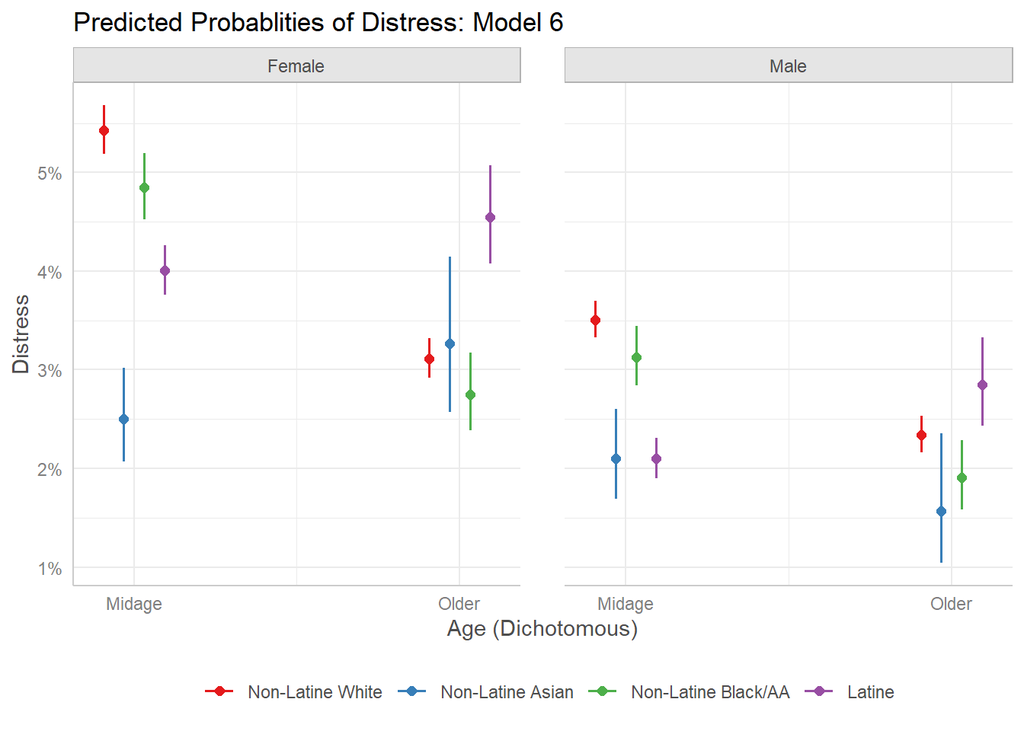

```r
#Plot code
plot(marginal_effects_mod6,
     facet = TRUE) +
  labs(title = "Predicted Probablities of Distress: Model 6",
       x = "Age (Dichotomous)",
       y = "Distress") +
  #scale_x_continuous(limits=c(18,85),breaks=c(18,25,35,45,55,65,75,85))+
  theme(legend.position="bottom",legend.title = element_blank())+
  guides(color=guide_legend(override.aes=list(fill=NA)))+
  theme(panel.spacing.x=unit(1.5, "lines"),panel.spacing.y=unit(1, "lines"))
```

```r
#Hypothesis test
hypothesis_test(marginal_effects_mod6)
```

```
## # Pairwise comparisons
##
## agestage      |                                    reth |          male |  Contrast |         95% CI |      p
## -------------------------------------------------------------------------------------------------------------
## Midage-Older  |       Non-Latine White-Non-Latine White | Female-Female |      0.02 | [ 0.02,  0.03] | < .001
## Midage-Midage |       Non-Latine White-Non-Latine Asian | Female-Female |      0.03 | [ 0.02,  0.03] | < .001
## Midage-Older  |       Non-Latine White-Non-Latine Asian | Female-Female |      0.02 | [ 0.01,  0.03] | < .001
## Midage-Midage |    Non-Latine White-Non-Latine Black/AA | Female-Female |  5.78e-03 | [ 0.00,  0.01] | 0.001
## Midage-Older  |    Non-Latine White-Non-Latine Black/AA | Female-Female |      0.03 | [ 0.02,  0.03] | < .001
## Midage-Midage |                 Non-Latine White-Latine | Female-Female |      0.01 | [ 0.01,  0.02] | < .001
## Midage-Older  |                 Non-Latine White-Latine | Female-Female |  8.79e-03 | [ 0.00,  0.01] | < .001
## Midage-Midage |       Non-Latine White-Non-Latine White |   Female-Male |      0.02 | [ 0.02,  0.02] | < .001
## Midage-Older  |       Non-Latine White-Non-Latine White |   Female-Male |      0.03 | [ 0.03,  0.03] | < .001
## Midage-Midage |       Non-Latine White-Non-Latine Asian |   Female-Male |      0.03 | [ 0.03,  0.04] | < .001
## Midage-Older  |       Non-Latine White-Non-Latine Asian |   Female-Male |      0.04 | [ 0.03,  0.05] | < .001
## Midage-Midage |    Non-Latine White-Non-Latine Black/AA |   Female-Male |      0.02 | [ 0.02,  0.03] | < .001
## Midage-Older  |    Non-Latine White-Non-Latine Black/AA |   Female-Male |      0.04 | [ 0.03,  0.04] | < .001
## Midage-Midage |                 Non-Latine White-Latine |   Female-Male |      0.03 | [ 0.03,  0.04] | < .001
## Midage-Older  |                 Non-Latine White-Latine |   Female-Male |      0.03 | [ 0.02,  0.03] | < .001
## Older-Midage  |       Non-Latine White-Non-Latine Asian | Female-Female |  6.13e-03 | [ 0.00,  0.01] | 0.017
## Older-Older   |       Non-Latine White-Non-Latine Asian | Female-Female | -1.53e-03 | [-0.01,  0.01] | 0.706
## Older-Midage  |    Non-Latine White-Non-Latine Black/AA | Female-Female |     -0.02 | [-0.02, -0.01] | < .001
## Older-Older   |    Non-Latine White-Non-Latine Black/AA | Female-Female |  3.63e-03 | [ 0.00,  0.01] | 0.086
## Older-Midage  |                 Non-Latine White-Latine | Female-Female | -8.91e-03 | [-0.01, -0.01] | < .001
## Older-Older   |                 Non-Latine White-Latine | Female-Female |     -0.01 | [-0.02, -0.01] | < .001
## Older-Midage  |       Non-Latine White-Non-Latine White |   Female-Male | -3.94e-03 | [-0.01,  0.00] | < .001
## Older-Older   |       Non-Latine White-Non-Latine White |   Female-Male |  7.73e-03 | [ 0.01,  0.01] | < .001
## Older-Midage  |       Non-Latine White-Non-Latine Asian |   Female-Male |      0.01 | [ 0.01,  0.01] | < .001
## Older-Older   |       Non-Latine White-Non-Latine Asian |   Female-Male |      0.02 | [ 0.01,  0.02] | < .001
## Older-Midage  |    Non-Latine White-Non-Latine Black/AA |   Female-Male | -1.69e-04 | [ 0.00,  0.00] | 0.921
## Older-Older   |    Non-Latine White-Non-Latine Black/AA |   Female-Male |      0.01 | [ 0.01,  0.02] | < .001
## Older-Midage  |                 Non-Latine White-Latine |   Female-Male |      0.01 | [ 0.01,  0.01] | < .001
## Older-Older   |                 Non-Latine White-Latine |   Female-Male |  2.69e-03 | [ 0.00,  0.01] | 0.257
## Midage-Older  |       Non-Latine Asian-Non-Latine Asian | Female-Female | -7.66e-03 | [-0.02,  0.00] | 0.096
## Midage-Midage |    Non-Latine Asian-Non-Latine Black/AA | Female-Female |     -0.02 | [-0.03, -0.02] | < .001
## Midage-Older  |    Non-Latine Asian-Non-Latine Black/AA | Female-Female | -2.50e-03 | [-0.01,  0.00] | 0.407
## Midage-Midage |                 Non-Latine Asian-Latine | Female-Female |     -0.02 | [-0.02, -0.01] | < .001
## Midage-Older  |                 Non-Latine Asian-Latine | Female-Female |     -0.02 | [-0.03, -0.01] | < .001
## Midage-Midage |       Non-Latine Asian-Non-Latine White |   Female-Male |     -0.01 | [-0.01, -0.01] | < .001
## Midage-Older  |       Non-Latine Asian-Non-Latine White |   Female-Male |  1.60e-03 | [ 0.00,  0.01] | 0.534
```

[output cut: 69 more lines]

```
## Midage-Older  |       Non-Latine Asian-Non-Latine Asian |     Male-Male |  5.30e-03 | [ 0.00,  0.01] | 0.181
## Midage-Midage |    Non-Latine Asian-Non-Latine Black/AA |     Male-Male |     -0.01 | [-0.02,  0.00] | < .001
## Midage-Older  |    Non-Latine Asian-Non-Latine Black/AA |     Male-Male |  1.98e-03 | [ 0.00,  0.01] | 0.491
## Midage-Midage |                 Non-Latine Asian-Latine |     Male-Male |  3.77e-05 | [ 0.00,  0.00] | 0.988
## Midage-Older  |                 Non-Latine Asian-Latine |     Male-Male | -7.44e-03 | [-0.01,  0.00] | 0.018
## Older-Midage  |    Non-Latine Asian-Non-Latine Black/AA |     Male-Male |     -0.02 | [-0.02, -0.01] | < .001
## Older-Older   |    Non-Latine Asian-Non-Latine Black/AA |     Male-Male | -3.33e-03 | [-0.01,  0.00] | 0.375
## Older-Midage  |                 Non-Latine Asian-Latine |     Male-Male | -5.27e-03 | [-0.01,  0.00] | 0.124
## Older-Older   |                 Non-Latine Asian-Latine |     Male-Male |     -0.01 | [-0.02, -0.01] | < .001
## Midage-Older  | Non-Latine Black/AA-Non-Latine Black/AA |     Male-Male |      0.01 | [ 0.01,  0.02] | < .001
## Midage-Midage |              Non-Latine Black/AA-Latine |     Male-Male |      0.01 | [ 0.01,  0.01] | < .001
## Midage-Older  |              Non-Latine Black/AA-Latine |     Male-Male |  2.86e-03 | [ 0.00,  0.01] | 0.288
## Older-Midage  |              Non-Latine Black/AA-Latine |     Male-Male | -1.94e-03 | [-0.01,  0.00] | 0.329
## Older-Older   |              Non-Latine Black/AA-Latine |     Male-Male | -9.42e-03 | [-0.01,  0.00] | < .001
## Midage-Older  |                           Latine-Latine |     Male-Male | -7.48e-03 | [-0.01,  0.00] | 0.002
```

```
##
## Contrasts are presented as probabilities.
```

Fun! We can see that 3-level models are very complex.